# The Impact of Marital Status on the Labor Force Composition: a case of the Dutch Economy

## Author: Elizabeth Qiu

### For data and other files, please visit: https://github.com/elizabethqiu/econ-research-paper

### Background

In the market system, the circular flow diagram helps illustrate the flow for a simplified economy without government presence, and where businesses and households both buy and sell in different markets: resource and product. Households sell land, labor, capital, and entrepreneurial ability in the resource market, and in the same market, businesses buy, causing households to earn income (wages, rent, interest, and profits). Similarly, in the product market, businesses sell their goods and services, which households buy (consumption expenditures).

In any economy, the labor force (or job market) will consist of anyone who is willing and able to work. It contains the natural rate of unemployment, due to frictional unemployment, where for example, people deliberatey choose to be temporarily unemployed in order to move from one job to another.

The labor force refers to the supply and demand for labor, and is a critical component of any economy. These metrics are influenced by a wide variety of factors on the macroeconomic level ("market dynamics, immigration, the age of the population, education levels, unemployment, productivity, participation rates, total income, and gross domestic product (GDP)") and the microeconomic level consists of "individual firms' interactions with employees" such as hiring, firing, raising or cutting wages and hours. The relationship between supply and demand influences how employees work and receive wages.

**Hypothesis:** If the percent of adults married increases, then the labor force percentage will also increase, because couples will need more income to pay for expenses.

### Fun Info

For my final economics project, I wanted to initially do some research on (Project #1) the effect of income changes on consumer choices for buying radishes, but I really couldn't find any consistent good data on sales. Also, I didn't know if radishes were a normal or inferior good :(

So instead, I randomly picked a happy country, because seeing happy people makes me super happy. Countries like Finland, Iceland, and the Netherlands are home to the happiest people in the world (Source: USAToday). However, I don't know much about the marital statuses of the people that live there (Project #3), and I thought it would be cool to analyze if it could impact or predict the size or makeup of the national labor force. Or maybe correlation doesn't imply causation!

So that's how my project selection process went from a radish case study to a Dutch marriage :)

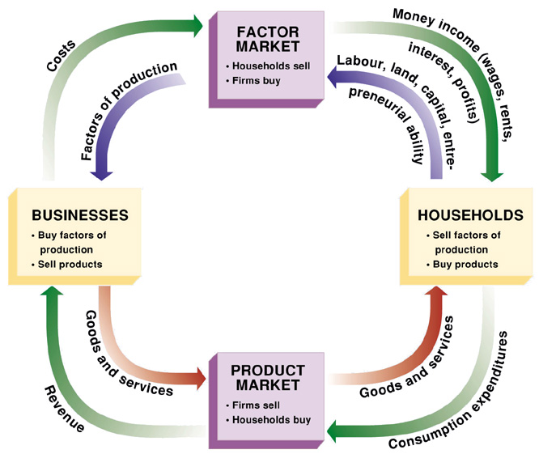

# Data!

## Datasets Used 💫

1. "World Development Indicators" from the [World Bank](https://data.worldbank.org/indicator/SL.TLF.TOTL.IN?end=2010&locations=NL&name_desc=false&start=2000&view=chart) to find the labor force population in the Netherlands each year from 2000 to 2010. (Last Updated: 04-27-2022)
2. "population; sex, age and marital status, January 1; 1950-2019" to find marriage metrics (I extracted data for 2000-2010, removed "widowed" and "divorced" metrics, and removed data under 20 years old) (10-year-olds should probably not be getting married, anyway). This was found on from [StatLine](https://opendata.cbs.nl/statline/#/CBS/en/dataset/7461ENG/table?fromstatweb) on the Dutch government website! And info is retrieved from CBS. (Last Updated: 07-15-2019)
3. I use the [World Inequity Database](https://wid.world/data/) to find Gross domestic product per capita in the Netherlands. (Last Updated: 2022)

[figure not shown]

[figure not shown]

[figure not shown]

```python
# Importing libraries 🪄
import csv
import pandas as pd
import numpy as np
import datetime
import matplotlib.pyplot as plt

# Dataset 1
# pd.set_option('display.max_columns', None)
## lfdata = pd.read_csv("Labor_Force.csv")
# print(lfdata.to_string())
# print(lfdata)
## lfdata.plot()

x = []
y = []

with open('Labor_Force.csv','r') as csvfile:
    lines = csv.reader(csvfile, delimiter=',')
    for row in lines:
        x.append(row[0])
        y.append(row[1])

plt.plot(x, y, color = 'b', linestyle = 'dashed',
         marker = 'o',label = "Labor Force Data")

plt.xticks(rotation = 25)
plt.xlabel('Year')
plt.ylabel('Population')
plt.title('Labor Force in the Netherlands', fontsize = 20)
plt.grid()
plt.legend()
plt.show()

# Dataset 2
psamsdata = pd.read_csv("PSAMS.csv")

x = []
y = []

with open('PSAMS.csv','r') as csvfile:
    lines = csv.reader(csvfile, delimiter=',')
    for row in lines:
        x.append(row[0])
        y.append(row[1])

plt.plot(x, y, color = 'b', linestyle = 'dashed',
         marker = 'o',label = "Marriage Data")

plt.xticks(rotation = 25)
plt.xlabel('Year')
plt.ylabel('People Married')
plt.title('Marriages in the Netherlands', fontsize = 20)
plt.grid()
plt.legend()
plt.show()

# download_url = (
#     "https://raw.githubusercontent.com/elizabethqiu/econ-research-paper/main/PSAMS.csv"
# )

# df = pd.read_csv(download_url)
# type(df)
# df.head()

# Dataset 3
gdpdata = pd.read_csv("GDP.csv")

x = []
y = []

with open('GDP.csv','r') as csvfile:
    lines = csv.reader(csvfile, delimiter=';')
    for row in lines:
        x.append(row[0])
        y.append(row[1])

plt.plot(x, y, color = 'b', linestyle = 'dashed',
         marker = 'o',label = "GDP Data")

plt.xticks(rotation = 25)
plt.xlabel('Year')
plt.ylabel('Euro (adjusted to USD value)')
plt.title('GDP in the Netherlands', fontsize = 20)
plt.grid()
plt.legend()
plt.show()
```

### Analysis and Conclusion

I noticed while doing research was that the average age at which people were getting married has been steadily rising in many parts of the world, and I wonder if that has any correlation to economics. In the Netherlands today, the average age for marriage occurs at 37, while in the United States, the average age is around 29. I personally think so, because especially women have been prioritizing their personal growth and careers more, which may delay personal plans. Or, potential couples could have been waiting to become more financially stable before getting married.

Another interesting note I found outside of class was the Microeconomics Theory of Fertility, which states that if there is an upward shift in income, it's possible to afford both more children and consumer goods. This suggests that poorer families may have less children that rich families.

### Further research

Economics is fascinating, and it's seriously so cool how any concept or thing can be analyzed through this lens. I could even write a paper on the economics of bananas and I'm sure I'd get many results.

If given more time, I'd love to find more data and analyze the effect of education and culture on marital status and economic growth. I also wonder if people choose life partners mainly from similar financial backgrounds. There may also be room to discover other factors and errors/biases in minimum wage, recessions, or even depressions. To find more patterns and comparisons on a larger scale, I'd compare this data to other countries, like the United States.

### Bibliography

Kenton, Will. “What Is the Labor Market?” Investopedia, Investopedia, 2 May 2022, https://www.investopedia.com/terms/l/labor-market.asp.

“Fertility Theory - Explore the Science & Experts: Idexlab.” Openisme, https://www.idexlab.com/openisme/topic-fertility-theory/.

“Family Economics.” Wikipedia, Wikimedia Foundation, 18 Apr. 2022, https://en.wikipedia.org/wiki/Family_economics.

“Labor Force, Total - Netherlands.” Data, https://data.worldbank.org/indicator/SL.TLF.TOTL.IN?end=2010&amp;locations=NL&amp;name_desc=false&amp;start=2000&amp;view=chart.

CBS Statline, https://opendata.cbs.nl/statline/#/CBS/en/dataset/7461ENG/table?fromstatweb.

“Data - Wid - World Inequality Database.” WID, https://wid.world/data/.

& lots of sites used to help me in Jupyter Notebook, like https://matplotlib.org and https://geeksforgeeks.org.

Thank you Ms. Malo for giving creative room to do whatever I wanted in this project :) I've wanted to (re)visit Jupyter Notebook and create something in it (done is better than perfect!) 😊.